# Risk Factor Analysis

## Outcome Variable

**Outcome Variable:** ever_co

## Predictor Variables

**Intervention Variable:** hhwealth_quart

**Adjustment Set:**

- arm
- sex
- W_mage
- meducyrs
- feducyrs
- W_gagebrth
- W_birthwt
- W_birthlen
- W_nchldlt5
- W_parity
- delta_W_mage
- delta_meducyrs
- delta_feducyrs
- delta_W_gagebrth
- delta_W_birthwt
- delta_W_birthlen
- delta_W_nchldlt5
- delta_W_parity

## Stratifying Variables

The analysis was stratified on these variable(s):

- agecat
- studyid
- country

## Data Summary

| agecat | studyid | country | hhwealth_quart | ever_co | n_cell | n |
| --- | --- | --- | --- | --- | --- | --- |
| 0-24 months | CMC-V-BCS-2002 | INDIA | Wealth Q4 | 0 | 76 | 373 |
| 0-24 months | CMC-V-BCS-2002 | INDIA | Wealth Q4 | 1 | 20 | 373 |
| 0-24 months | CMC-V-BCS-2002 | INDIA | Wealth Q1 | 0 | 75 | 373 |
| 0-24 months | CMC-V-BCS-2002 | INDIA | Wealth Q1 | 1 | 16 | 373 |
| 0-24 months | CMC-V-BCS-2002 | INDIA | Wealth Q2 | 0 | 69 | 373 |
| 0-24 months | CMC-V-BCS-2002 | INDIA | Wealth Q2 | 1 | 26 | 373 |
| 0-24 months | CMC-V-BCS-2002 | INDIA | Wealth Q3 | 0 | 67 | 373 |
| 0-24 months | CMC-V-BCS-2002 | INDIA | Wealth Q3 | 1 | 24 | 373 |
| 0-24 months | COHORTS | GUATEMALA | Wealth Q4 | 0 | 434 | 1263 |
| 0-24 months | COHORTS | GUATEMALA | Wealth Q4 | 1 | 42 | 1263 |
| 0-24 months | COHORTS | GUATEMALA | Wealth Q1 | 0 | 212 | 1263 |
| 0-24 months | COHORTS | GUATEMALA | Wealth Q1 | 1 | 32 | 1263 |
| 0-24 months | COHORTS | GUATEMALA | Wealth Q2 | 0 | 222 | 1263 |
| 0-24 months | COHORTS | GUATEMALA | Wealth Q2 | 1 | 36 | 1263 |
| 0-24 months | COHORTS | GUATEMALA | Wealth Q3 | 0 | 251 | 1263 |
| 0-24 months | COHORTS | GUATEMALA | Wealth Q3 | 1 | 34 | 1263 |
| 0-24 months | COHORTS | PHILIPPINES | Wealth Q4 | 0 | 753 | 3044 |
| 0-24 months | COHORTS | PHILIPPINES | Wealth Q4 | 1 | 87 | 3044 |
| 0-24 months | COHORTS | PHILIPPINES | Wealth Q1 | 0 | 511 | 3044 |
| 0-24 months | COHORTS | PHILIPPINES | Wealth Q1 | 1 | 170 | 3044 |
| 0-24 months | COHORTS | PHILIPPINES | Wealth Q2 | 0 | 439 | 3044 |
| 0-24 months | COHORTS | PHILIPPINES | Wealth Q2 | 1 | 101 | 3044 |
| 0-24 months | COHORTS | PHILIPPINES | Wealth Q3 | 0 | 781 | 3044 |
| 0-24 months | COHORTS | PHILIPPINES | Wealth Q3 | 1 | 202 | 3044 |
| 0-24 months | CONTENT | PERU | Wealth Q4 | 0 | 52 | 215 |
| 0-24 months | CONTENT | PERU | Wealth Q4 | 1 | 0 | 215 |
| 0-24 months | CONTENT | PERU | Wealth Q1 | 0 | 59 | 215 |
| 0-24 months | CONTENT | PERU | Wealth Q1 | 1 | 0 | 215 |
| 0-24 months | CONTENT | PERU | Wealth Q2 | 0 | 52 | 215 |
| 0-24 months | CONTENT | PERU | Wealth Q2 | 1 | 0 | 215 |

[output cut: 402 more lines]

The following strata were considered:

- agecat: 0-24 months, studyid: CMC-V-BCS-2002, country: INDIA
- agecat: 0-24 months, studyid: COHORTS, country: GUATEMALA
- agecat: 0-24 months, studyid: COHORTS, country: PHILIPPINES
- agecat: 0-24 months, studyid: CONTENT, country: PERU
- agecat: 0-24 months, studyid: GMS-Nepal, country: NEPAL
- agecat: 0-24 months, studyid: IRC, country: INDIA
- agecat: 0-24 months, studyid: JiVitA-3, country: BANGLADESH
- agecat: 0-24 months, studyid: JiVitA-4, country: BANGLADESH
- agecat: 0-24 months, studyid: LCNI-5, country: MALAWI
- agecat: 0-24 months, studyid: MAL-ED, country: BANGLADESH
- agecat: 0-24 months, studyid: MAL-ED, country: BRAZIL
- agecat: 0-24 months, studyid: MAL-ED, country: INDIA
- agecat: 0-24 months, studyid: MAL-ED, country: NEPAL
- agecat: 0-24 months, studyid: MAL-ED, country: PERU
- agecat: 0-24 months, studyid: MAL-ED, country: SOUTH AFRICA
- agecat: 0-24 months, studyid: MAL-ED, country: TANZANIA, UNITED REPUBLIC OF
- agecat: 0-24 months, studyid: PROVIDE, country: BANGLADESH
- agecat: 0-24 months, studyid: TanzaniaChild2, country: TANZANIA, UNITED REPUBLIC OF
- agecat: 0-6 months, studyid: CMC-V-BCS-2002, country: INDIA
- agecat: 0-6 months, studyid: COHORTS, country: GUATEMALA
- agecat: 0-6 months, studyid: COHORTS, country: PHILIPPINES
- agecat: 0-6 months, studyid: CONTENT, country: PERU
- agecat: 0-6 months, studyid: GMS-Nepal, country: NEPAL
- agecat: 0-6 months, studyid: IRC, country: INDIA
- agecat: 0-6 months, studyid: JiVitA-3, country: BANGLADESH
- agecat: 0-6 months, studyid: JiVitA-4, country: BANGLADESH
- agecat: 0-6 months, studyid: LCNI-5, country: MALAWI
- agecat: 0-6 months, studyid: MAL-ED, country: BANGLADESH
- agecat: 0-6 months, studyid: MAL-ED, country: BRAZIL
- agecat: 0-6 months, studyid: MAL-ED, country: INDIA
- agecat: 0-6 months, studyid: MAL-ED, country: NEPAL
- agecat: 0-6 months, studyid: MAL-ED, country: PERU
- agecat: 0-6 months, studyid: MAL-ED, country: SOUTH AFRICA
- agecat: 0-6 months, studyid: MAL-ED, country: TANZANIA, UNITED REPUBLIC OF
- agecat: 0-6 months, studyid: PROVIDE, country: BANGLADESH
- agecat: 0-6 months, studyid: TanzaniaChild2, country: TANZANIA, UNITED REPUBLIC OF
- agecat: 6-24 months, studyid: CMC-V-BCS-2002, country: INDIA
- agecat: 6-24 months, studyid: COHORTS, country: GUATEMALA
- agecat: 6-24 months, studyid: COHORTS, country: PHILIPPINES
- agecat: 6-24 months, studyid: CONTENT, country: PERU
- agecat: 6-24 months, studyid: GMS-Nepal, country: NEPAL
- agecat: 6-24 months, studyid: IRC, country: INDIA
- agecat: 6-24 months, studyid: JiVitA-3, country: BANGLADESH
- agecat: 6-24 months, studyid: JiVitA-4, country: BANGLADESH
- agecat: 6-24 months, studyid: LCNI-5, country: MALAWI
- agecat: 6-24 months, studyid: MAL-ED, country: BANGLADESH
- agecat: 6-24 months, studyid: MAL-ED, country: BRAZIL
- agecat: 6-24 months, studyid: MAL-ED, country: INDIA
- agecat: 6-24 months, studyid: MAL-ED, country: NEPAL
- agecat: 6-24 months, studyid: MAL-ED, country: PERU
- agecat: 6-24 months, studyid: MAL-ED, country: SOUTH AFRICA
- agecat: 6-24 months, studyid: MAL-ED, country: TANZANIA, UNITED REPUBLIC OF
- agecat: 6-24 months, studyid: PROVIDE, country: BANGLADESH
- agecat: 6-24 months, studyid: TanzaniaChild2, country: TANZANIA, UNITED REPUBLIC OF

### Dropped Strata

Some strata were dropped due to rare outcomes:

- agecat: 0-24 months, studyid: CONTENT, country: PERU
- agecat: 0-24 months, studyid: MAL-ED, country: BRAZIL
- agecat: 0-24 months, studyid: MAL-ED, country: NEPAL
- agecat: 0-24 months, studyid: MAL-ED, country: PERU
- agecat: 0-24 months, studyid: MAL-ED, country: SOUTH AFRICA
- agecat: 0-24 months, studyid: MAL-ED, country: TANZANIA, UNITED REPUBLIC OF
- agecat: 0-6 months, studyid: CMC-V-BCS-2002, country: INDIA
- agecat: 0-6 months, studyid: COHORTS, country: GUATEMALA
- agecat: 0-6 months, studyid: CONTENT, country: PERU
- agecat: 0-6 months, studyid: LCNI-5, country: MALAWI
- agecat: 0-6 months, studyid: MAL-ED, country: BANGLADESH
- agecat: 0-6 months, studyid: MAL-ED, country: BRAZIL
- agecat: 0-6 months, studyid: MAL-ED, country: INDIA
- agecat: 0-6 months, studyid: MAL-ED, country: NEPAL
- agecat: 0-6 months, studyid: MAL-ED, country: PERU
- agecat: 0-6 months, studyid: MAL-ED, country: SOUTH AFRICA
- agecat: 0-6 months, studyid: MAL-ED, country: TANZANIA, UNITED REPUBLIC OF
- agecat: 0-6 months, studyid: PROVIDE, country: BANGLADESH
- agecat: 0-6 months, studyid: TanzaniaChild2, country: TANZANIA, UNITED REPUBLIC OF
- agecat: 6-24 months, studyid: CONTENT, country: PERU
- agecat: 6-24 months, studyid: MAL-ED, country: BRAZIL
- agecat: 6-24 months, studyid: MAL-ED, country: NEPAL
- agecat: 6-24 months, studyid: MAL-ED, country: PERU
- agecat: 6-24 months, studyid: MAL-ED, country: SOUTH AFRICA
- agecat: 6-24 months, studyid: MAL-ED, country: TANZANIA, UNITED REPUBLIC OF

## Methods Detail

We’re interested in the causal parameters $E[Y_a]$ for all values of $a \in \mathcal{A}$. These parameters represent the mean outcome if, possibly contrary to fact, we intervened to set all units to have $A=a$. Under the randomization and positivity assumptions, these are identified by the statistical parameters $\psi_a=E_W[E_{Y|A,W}(Y|A=a,W)]$. In addition, we’re interested in the mean of $Y$, $E[Y]$ under no intervention (the observed mean). We will estimate these parameters by using SuperLearner to fit the relevant likelihood factors – $E_{Y|A,W}(Y|A=a,W)$ and $p(A=a|W)$, and then updating our likelihood fit using a joint TMLE.

For unadjusted analyses ($W=\{\}$), initial likelihoods were estimated using Lrnr_glm to estimate the simple $E(Y|A)$ and Lrnr_mean to estimate $p(A)$. For adjusted analyses, a small library containing Lrnr_glmnet, Lrnr_xgboost, and Lrnr_mean was used.

Having estimated these parameters, we will then use the delta method to estimate relative risks and attributable risks relative to a prespecified baseline level of $A$.

# Results Detail

## Results Plots

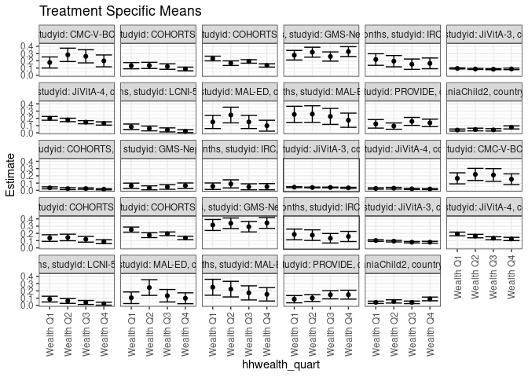

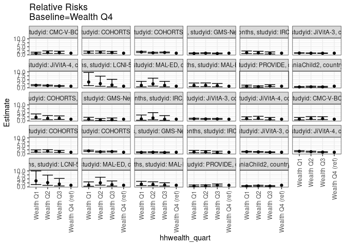

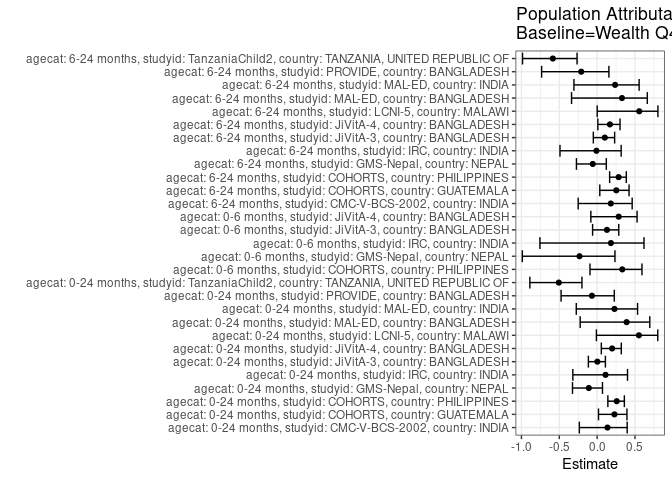

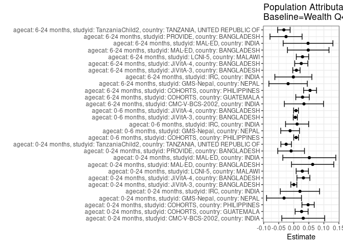

## Results Table

### Parameter: TSM

| agecat | studyid | country | intervention_level | baseline_level | estimate | ci_lower | ci_upper |
| --- | --- | --- | --- | --- | --- | --- | --- |
| 0-24 months | CMC-V-BCS-2002 | INDIA | Wealth Q4 | NA | 0.1990356 | 0.1174755 | 0.2805957 |
| 0-24 months | CMC-V-BCS-2002 | INDIA | Wealth Q1 | NA | 0.1770908 | 0.1007503 | 0.2534313 |
| 0-24 months | CMC-V-BCS-2002 | INDIA | Wealth Q2 | NA | 0.2823274 | 0.1899397 | 0.3747151 |
| 0-24 months | CMC-V-BCS-2002 | INDIA | Wealth Q3 | NA | 0.2621545 | 0.1717058 | 0.3526031 |
| 0-24 months | COHORTS | GUATEMALA | Wealth Q4 | NA | 0.0879639 | 0.0625554 | 0.1133724 |
| 0-24 months | COHORTS | GUATEMALA | Wealth Q1 | NA | 0.1326568 | 0.0899340 | 0.1753797 |
| 0-24 months | COHORTS | GUATEMALA | Wealth Q2 | NA | 0.1365433 | 0.0941576 | 0.1789289 |
| 0-24 months | COHORTS | GUATEMALA | Wealth Q3 | NA | 0.1208090 | 0.0830379 | 0.1585801 |
| 0-24 months | COHORTS | PHILIPPINES | Wealth Q4 | NA | 0.1363905 | 0.1142570 | 0.1585240 |
| 0-24 months | COHORTS | PHILIPPINES | Wealth Q1 | NA | 0.2317372 | 0.1994665 | 0.2640079 |
| 0-24 months | COHORTS | PHILIPPINES | Wealth Q2 | NA | 0.1673769 | 0.1356092 | 0.1991447 |
| 0-24 months | COHORTS | PHILIPPINES | Wealth Q3 | NA | 0.1917000 | 0.1673524 | 0.2160475 |
| 0-24 months | GMS-Nepal | NEPAL | Wealth Q4 | NA | 0.3268178 | 0.2588905 | 0.3947451 |
| 0-24 months | GMS-Nepal | NEPAL | Wealth Q1 | NA | 0.2772041 | 0.2110966 | 0.3433115 |
| 0-24 months | GMS-Nepal | NEPAL | Wealth Q2 | NA | 0.3188079 | 0.2503048 | 0.3873110 |
| 0-24 months | GMS-Nepal | NEPAL | Wealth Q3 | NA | 0.2593988 | 0.1960442 | 0.3227534 |
| 0-24 months | IRC | INDIA | Wealth Q4 | NA | 0.1648436 | 0.0906824 | 0.2390049 |
| 0-24 months | IRC | INDIA | Wealth Q1 | NA | 0.2176699 | 0.1377308 | 0.2976090 |
| 0-24 months | IRC | INDIA | Wealth Q2 | NA | 0.1951068 | 0.1173441 | 0.2728695 |
| 0-24 months | IRC | INDIA | Wealth Q3 | NA | 0.1531780 | 0.0815842 | 0.2247719 |
| 0-24 months | JiVitA-3 | BANGLADESH | Wealth Q4 | NA | 0.0885468 | 0.0777553 | 0.0993383 |
| 0-24 months | JiVitA-3 | BANGLADESH | Wealth Q1 | NA | 0.0952260 | 0.0871459 | 0.1033061 |
| 0-24 months | JiVitA-3 | BANGLADESH | Wealth Q2 | NA | 0.0878250 | 0.0800889 | 0.0955610 |
| 0-24 months | JiVitA-3 | BANGLADESH | Wealth Q3 | NA | 0.0849322 | 0.0777427 | 0.0921217 |
| 0-24 months | JiVitA-4 | BANGLADESH | Wealth Q4 | NA | 0.1294488 | 0.1072741 | 0.1516236 |
| 0-24 months | JiVitA-4 | BANGLADESH | Wealth Q1 | NA | 0.1996602 | 0.1736599 | 0.2256605 |
| 0-24 months | JiVitA-4 | BANGLADESH | Wealth Q2 | NA | 0.1778845 | 0.1542599 | 0.2015092 |
| 0-24 months | JiVitA-4 | BANGLADESH | Wealth Q3 | NA | 0.1461751 | 0.1246905 | 0.1676597 |
| 0-24 months | LCNI-5 | MALAWI | Wealth Q4 | NA | 0.0230415 | 0.0030669 | 0.0430160 |
| 0-24 months | LCNI-5 | MALAWI | Wealth Q1 | NA | 0.0833333 | 0.0453831 | 0.1212835 |

[output cut: 86 more lines]

### Parameter: E(Y)

| agecat | studyid | country | intervention_level | baseline_level | estimate | ci_lower | ci_upper |
| --- | --- | --- | --- | --- | --- | --- | --- |
| 0-24 months | CMC-V-BCS-2002 | INDIA | NA | NA | 0.2305630 | 0.1877616 | 0.2733644 |
| 0-24 months | COHORTS | GUATEMALA | NA | NA | 0.1140143 | 0.0964790 | 0.1315495 |
| 0-24 months | COHORTS | PHILIPPINES | NA | NA | 0.1839685 | 0.1702020 | 0.1977349 |
| 0-24 months | GMS-Nepal | NEPAL | NA | NA | 0.2944606 | 0.2603274 | 0.3285938 |
| 0-24 months | IRC | INDIA | NA | NA | 0.1853659 | 0.1477057 | 0.2230261 |
| 0-24 months | JiVitA-3 | BANGLADESH | NA | NA | 0.0888137 | 0.0849063 | 0.0927211 |
| 0-24 months | JiVitA-4 | BANGLADESH | NA | NA | 0.1614449 | 0.1501252 | 0.1727646 |
| 0-24 months | LCNI-5 | MALAWI | NA | NA | 0.0514076 | 0.0362561 | 0.0665591 |
| 0-24 months | MAL-ED | BANGLADESH | NA | NA | 0.1611570 | 0.1147371 | 0.2075770 |
| 0-24 months | MAL-ED | INDIA | NA | NA | 0.2255319 | 0.1719836 | 0.2790802 |
| 0-24 months | PROVIDE | BANGLADESH | NA | NA | 0.1285714 | 0.1037574 | 0.1533855 |
| 0-24 months | TanzaniaChild2 | TANZANIA, UNITED REPUBLIC OF | NA | NA | 0.0499161 | 0.0411726 | 0.0586596 |
| 0-6 months | COHORTS | PHILIPPINES | NA | NA | 0.0236609 | 0.0182597 | 0.0290620 |
| 0-6 months | GMS-Nepal | NEPAL | NA | NA | 0.0524781 | 0.0357793 | 0.0691770 |
| 0-6 months | IRC | INDIA | NA | NA | 0.0611247 | 0.0378797 | 0.0843697 |
| 0-6 months | JiVitA-3 | BANGLADESH | NA | NA | 0.0396387 | 0.0371359 | 0.0421415 |
| 0-6 months | JiVitA-4 | BANGLADESH | NA | NA | 0.0263831 | 0.0210411 | 0.0317252 |
| 6-24 months | CMC-V-BCS-2002 | INDIA | NA | NA | 0.1876676 | 0.1479906 | 0.2273445 |
| 6-24 months | COHORTS | GUATEMALA | NA | NA | 0.1153513 | 0.0969046 | 0.1337979 |
| 6-24 months | COHORTS | PHILIPPINES | NA | NA | 0.1908832 | 0.1763448 | 0.2054216 |
| 6-24 months | GMS-Nepal | NEPAL | NA | NA | 0.3254237 | 0.2875855 | 0.3632619 |
| 6-24 months | IRC | INDIA | NA | NA | 0.1560976 | 0.1209228 | 0.1912723 |
| 6-24 months | JiVitA-3 | BANGLADESH | NA | NA | 0.0867929 | 0.0821342 | 0.0914516 |
| 6-24 months | JiVitA-4 | BANGLADESH | NA | NA | 0.1477315 | 0.1371478 | 0.1583151 |
| 6-24 months | LCNI-5 | MALAWI | NA | NA | 0.0521739 | 0.0368026 | 0.0675452 |
| 6-24 months | MAL-ED | BANGLADESH | NA | NA | 0.1464435 | 0.1015265 | 0.1913605 |
| 6-24 months | MAL-ED | INDIA | NA | NA | 0.2000000 | 0.1487493 | 0.2512507 |
| 6-24 months | PROVIDE | BANGLADESH | NA | NA | 0.1221498 | 0.0962275 | 0.1480722 |
| 6-24 months | TanzaniaChild2 | TANZANIA, UNITED REPUBLIC OF | NA | NA | 0.0562469 | 0.0461696 | 0.0663242 |

### Parameter: RR

| agecat | studyid | country | intervention_level | baseline_level | estimate | ci_lower | ci_upper |
| --- | --- | --- | --- | --- | --- | --- | --- |
| 0-24 months | CMC-V-BCS-2002 | INDIA | Wealth Q4 | Wealth Q4 | 1.0000000 | 1.0000000 | 1.0000000 |
| 0-24 months | CMC-V-BCS-2002 | INDIA | Wealth Q1 | Wealth Q4 | 0.8897446 | 0.4926451 | 1.6069284 |
| 0-24 months | CMC-V-BCS-2002 | INDIA | Wealth Q2 | Wealth Q4 | 1.4184771 | 0.8374482 | 2.4026288 |
| 0-24 months | CMC-V-BCS-2002 | INDIA | Wealth Q3 | Wealth Q4 | 1.3171237 | 0.7730679 | 2.2440654 |
| 0-24 months | COHORTS | GUATEMALA | Wealth Q4 | Wealth Q4 | 1.0000000 | 1.0000000 | 1.0000000 |
| 0-24 months | COHORTS | GUATEMALA | Wealth Q1 | Wealth Q4 | 1.5080831 | 0.9788297 | 2.3235040 |
| 0-24 months | COHORTS | GUATEMALA | Wealth Q2 | Wealth Q4 | 1.5522652 | 1.0164939 | 2.3704297 |
| 0-24 months | COHORTS | GUATEMALA | Wealth Q3 | Wealth Q4 | 1.3733928 | 0.8977849 | 2.1009574 |
| 0-24 months | COHORTS | PHILIPPINES | Wealth Q4 | Wealth Q4 | 1.0000000 | 1.0000000 | 1.0000000 |
| 0-24 months | COHORTS | PHILIPPINES | Wealth Q1 | Wealth Q4 | 1.6990715 | 1.3741483 | 2.1008242 |
| 0-24 months | COHORTS | PHILIPPINES | Wealth Q2 | Wealth Q4 | 1.2271892 | 0.9578991 | 1.5721836 |
| 0-24 months | COHORTS | PHILIPPINES | Wealth Q3 | Wealth Q4 | 1.4055231 | 1.1468977 | 1.7224685 |
| 0-24 months | GMS-Nepal | NEPAL | Wealth Q4 | Wealth Q4 | 1.0000000 | 1.0000000 | 1.0000000 |
| 0-24 months | GMS-Nepal | NEPAL | Wealth Q1 | Wealth Q4 | 0.8481914 | 0.6205572 | 1.1593269 |
| 0-24 months | GMS-Nepal | NEPAL | Wealth Q2 | Wealth Q4 | 0.9754912 | 0.7258500 | 1.3109913 |
| 0-24 months | GMS-Nepal | NEPAL | Wealth Q3 | Wealth Q4 | 0.7937107 | 0.5784659 | 1.0890473 |
| 0-24 months | IRC | INDIA | Wealth Q4 | Wealth Q4 | 1.0000000 | 1.0000000 | 1.0000000 |
| 0-24 months | IRC | INDIA | Wealth Q1 | Wealth Q4 | 1.3204631 | 0.7390952 | 2.3591315 |
| 0-24 months | IRC | INDIA | Wealth Q2 | Wealth Q4 | 1.1835871 | 0.6487637 | 2.1593048 |
| 0-24 months | IRC | INDIA | Wealth Q3 | Wealth Q4 | 0.9292324 | 0.4857292 | 1.7776836 |
| 0-24 months | JiVitA-3 | BANGLADESH | Wealth Q4 | Wealth Q4 | 1.0000000 | 1.0000000 | 1.0000000 |
| 0-24 months | JiVitA-3 | BANGLADESH | Wealth Q1 | Wealth Q4 | 1.0754312 | 0.9267212 | 1.2480046 |
| 0-24 months | JiVitA-3 | BANGLADESH | Wealth Q2 | Wealth Q4 | 0.9918479 | 0.8611231 | 1.1424176 |
| 0-24 months | JiVitA-3 | BANGLADESH | Wealth Q3 | Wealth Q4 | 0.9591785 | 0.8295584 | 1.1090519 |
| 0-24 months | JiVitA-4 | BANGLADESH | Wealth Q4 | Wealth Q4 | 1.0000000 | 1.0000000 | 1.0000000 |
| 0-24 months | JiVitA-4 | BANGLADESH | Wealth Q1 | Wealth Q4 | 1.5423872 | 1.2438938 | 1.9125091 |
| 0-24 months | JiVitA-4 | BANGLADESH | Wealth Q2 | Wealth Q4 | 1.3741687 | 1.1061256 | 1.7071657 |
| 0-24 months | JiVitA-4 | BANGLADESH | Wealth Q3 | Wealth Q4 | 1.1292112 | 0.9011150 | 1.4150445 |
| 0-24 months | LCNI-5 | MALAWI | Wealth Q4 | Wealth Q4 | 1.0000000 | 1.0000000 | 1.0000000 |
| 0-24 months | LCNI-5 | MALAWI | Wealth Q1 | Wealth Q4 | 3.6166667 | 1.3584145 | 9.6290769 |

[output cut: 86 more lines]

### Parameter: PAR

| agecat | studyid | country | intervention_level | baseline_level | estimate | ci_lower | ci_upper |
| --- | --- | --- | --- | --- | --- | --- | --- |
| 0-24 months | CMC-V-BCS-2002 | INDIA | Wealth Q4 | NA | 0.0315274 | -0.0397874 | 0.1028423 |
| 0-24 months | COHORTS | GUATEMALA | Wealth Q4 | NA | 0.0260504 | 0.0045355 | 0.0475652 |
| 0-24 months | COHORTS | PHILIPPINES | Wealth Q4 | NA | 0.0475780 | 0.0271608 | 0.0679952 |
| 0-24 months | GMS-Nepal | NEPAL | Wealth Q4 | NA | -0.0323572 | -0.0903162 | 0.0256019 |
| 0-24 months | IRC | INDIA | Wealth Q4 | NA | 0.0205222 | -0.0446958 | 0.0857402 |
| 0-24 months | JiVitA-3 | BANGLADESH | Wealth Q4 | NA | 0.0002669 | -0.0096986 | 0.0102324 |
| 0-24 months | JiVitA-4 | BANGLADESH | Wealth Q4 | NA | 0.0319961 | 0.0104246 | 0.0535675 |
| 0-24 months | LCNI-5 | MALAWI | Wealth Q4 | NA | 0.0283661 | 0.0079551 | 0.0487771 |
| 0-24 months | MAL-ED | BANGLADESH | Wealth Q4 | NA | 0.0627964 | -0.0074582 | 0.1330510 |
| 0-24 months | MAL-ED | INDIA | Wealth Q4 | NA | 0.0516925 | -0.0363756 | 0.1397605 |
| 0-24 months | PROVIDE | BANGLADESH | Wealth Q4 | NA | -0.0088375 | -0.0532731 | 0.0355980 |
| 0-24 months | TanzaniaChild2 | TANZANIA, UNITED REPUBLIC OF | Wealth Q4 | NA | -0.0252563 | -0.0428044 | -0.0077083 |
| 0-6 months | COHORTS | PHILIPPINES | Wealth Q4 | NA | 0.0078554 | -0.0001370 | 0.0158477 |
| 0-6 months | GMS-Nepal | NEPAL | Wealth Q4 | NA | -0.0122277 | -0.0433663 | 0.0189108 |
| 0-6 months | IRC | INDIA | Wealth Q4 | NA | 0.0111247 | -0.0272816 | 0.0495309 |
| 0-6 months | JiVitA-3 | BANGLADESH | Wealth Q4 | NA | 0.0051445 | -0.0016644 | 0.0119534 |
| 0-6 months | JiVitA-4 | BANGLADESH | Wealth Q4 | NA | 0.0075126 | -0.0005110 | 0.0155363 |
| 6-24 months | CMC-V-BCS-2002 | INDIA | Wealth Q4 | NA | 0.0338527 | -0.0313042 | 0.0990096 |
| 6-24 months | COHORTS | GUATEMALA | Wealth Q4 | NA | 0.0291832 | 0.0067137 | 0.0516527 |
| 6-24 months | COHORTS | PHILIPPINES | Wealth Q4 | NA | 0.0541451 | 0.0326858 | 0.0756043 |
| 6-24 months | GMS-Nepal | NEPAL | Wealth Q4 | NA | -0.0188283 | -0.0826677 | 0.0450111 |
| 6-24 months | IRC | INDIA | Wealth Q4 | NA | -0.0013805 | -0.0628786 | 0.0601175 |
| 6-24 months | JiVitA-3 | BANGLADESH | Wealth Q4 | NA | 0.0087933 | -0.0034087 | 0.0209953 |
| 6-24 months | JiVitA-4 | BANGLADESH | Wealth Q4 | NA | 0.0249290 | 0.0031526 | 0.0467054 |
| 6-24 months | LCNI-5 | MALAWI | Wealth Q4 | NA | 0.0290258 | 0.0084625 | 0.0495890 |
| 6-24 months | MAL-ED | BANGLADESH | Wealth Q4 | NA | 0.0480829 | -0.0209323 | 0.1170980 |
| 6-24 months | MAL-ED | INDIA | Wealth Q4 | NA | 0.0474576 | -0.0352170 | 0.1301323 |
| 6-24 months | PROVIDE | BANGLADESH | Wealth Q4 | NA | -0.0256412 | -0.0789781 | 0.0276956 |
| 6-24 months | TanzaniaChild2 | TANZANIA, UNITED REPUBLIC OF | Wealth Q4 | NA | -0.0329136 | -0.0537456 | -0.0120816 |

### Parameter: PAF

| agecat | studyid | country | intervention_level | baseline_level | estimate | ci_lower | ci_upper |
| --- | --- | --- | --- | --- | --- | --- | --- |
| 0-24 months | CMC-V-BCS-2002 | INDIA | Wealth Q4 | NA | 0.1367410 | -0.2351447 | 0.3966569 |
| 0-24 months | COHORTS | GUATEMALA | Wealth Q4 | NA | 0.2284835 | 0.0179606 | 0.3938758 |
| 0-24 months | COHORTS | PHILIPPINES | Wealth Q4 | NA | 0.2586203 | 0.1416236 | 0.3596703 |
| 0-24 months | GMS-Nepal | NEPAL | Wealth Q4 | NA | -0.1098862 | -0.3253970 | 0.0705823 |
| 0-24 months | IRC | INDIA | Wealth Q4 | NA | 0.1107121 | -0.3207837 | 0.4012397 |
| 0-24 months | JiVitA-3 | BANGLADESH | Wealth Q4 | NA | 0.0030052 | -0.1157636 | 0.1091316 |
| 0-24 months | JiVitA-4 | BANGLADESH | Wealth Q4 | NA | 0.1981857 | 0.0553769 | 0.3194045 |
| 0-24 months | LCNI-5 | MALAWI | Wealth Q4 | NA | 0.5517885 | -0.0096188 | 0.8010204 |
| 0-24 months | MAL-ED | BANGLADESH | Wealth Q4 | NA | 0.3896595 | -0.2240431 | 0.6956680 |
| 0-24 months | MAL-ED | INDIA | Wealth Q4 | NA | 0.2292024 | -0.2755807 | 0.5342287 |
| 0-24 months | PROVIDE | BANGLADESH | Wealth Q4 | NA | -0.0687364 | -0.4764571 | 0.2263930 |
| 0-24 months | TanzaniaChild2 | TANZANIA, UNITED REPUBLIC OF | Wealth Q4 | NA | -0.5059756 | -0.8889248 | -0.2006633 |
| 0-6 months | COHORTS | PHILIPPINES | Wealth Q4 | NA | 0.3319978 | -0.0942402 | 0.5922038 |
| 0-6 months | GMS-Nepal | NEPAL | Wealth Q4 | NA | -0.2330065 | -0.9886031 | 0.2354909 |
| 0-6 months | IRC | INDIA | Wealth Q4 | NA | 0.1820000 | -0.7560322 | 0.6189569 |
| 0-6 months | JiVitA-3 | BANGLADESH | Wealth Q4 | NA | 0.1297852 | -0.0600318 | 0.2856121 |
| 0-6 months | JiVitA-4 | BANGLADESH | Wealth Q4 | NA | 0.2847516 | -0.0830526 | 0.5276497 |
| 6-24 months | CMC-V-BCS-2002 | INDIA | Wealth Q4 | NA | 0.1803866 | -0.2505915 | 0.4628412 |
| 6-24 months | COHORTS | GUATEMALA | Wealth Q4 | NA | 0.2529944 | 0.0350915 | 0.4216888 |
| 6-24 months | COHORTS | PHILIPPINES | Wealth Q4 | NA | 0.2836556 | 0.1651665 | 0.3853274 |
| 6-24 months | GMS-Nepal | NEPAL | Wealth Q4 | NA | -0.0578578 | -0.2734511 | 0.1212360 |
| 6-24 months | IRC | INDIA | Wealth Q4 | NA | -0.0088441 | -0.4908880 | 0.3173421 |
| 6-24 months | JiVitA-3 | BANGLADESH | Wealth Q4 | NA | 0.1013133 | -0.0502996 | 0.2310405 |
| 6-24 months | JiVitA-4 | BANGLADESH | Wealth Q4 | NA | 0.1687453 | 0.0093872 | 0.3024678 |
| 6-24 months | LCNI-5 | MALAWI | Wealth Q4 | NA | 0.5563272 | 0.0006791 | 0.8030206 |
| 6-24 months | MAL-ED | BANGLADESH | Wealth Q4 | NA | 0.3283372 | -0.3380546 | 0.6628457 |
| 6-24 months | MAL-ED | INDIA | Wealth Q4 | NA | 0.2372881 | -0.3066459 | 0.5547919 |
| 6-24 months | PROVIDE | BANGLADESH | Wealth Q4 | NA | -0.2099161 | -0.7334717 | 0.1555115 |
| 6-24 months | TanzaniaChild2 | TANZANIA, UNITED REPUBLIC OF | Wealth Q4 | NA | -0.5851635 | -0.9859968 | -0.2652303 |